# FABP4/GPT-4 classifier - Validation cohort

Here I will analyze COMET data to test how well we can predict LRTI using FABP4 and Versa.

I will feed variance stabilization transformed FABP4 expression level, and Versa LRTI score (between 0 and 3) to a logistic regression model.

# Load packages

```r
library(tidyverse)
library(ggplot2)
# library(ggalluvial)
library(patchwork)

# library(limma)
library(DESeq2)
library(pROC)
which.script <- "validation_cohort.Rmd"
```

Specify ggplot2 theme

```r
# General theme
my.theme <- theme(
  plot.title = element_text(hjust = 0.5, size=12, face="plain"),
  axis.text = element_text(size=12, color="black"),
  text = element_text(size=12, family="Arial"),
  panel.grid.major = element_blank(),
  panel.grid.minor = element_blank(),
  plot.margin = unit(c(0.3,1,0.7,0), "cm")
  )

# Confusion matrix theme
my.theme.cm <- theme(
  plot.title = element_text(hjust = 0.5, size=12, face="plain"),
  text = element_text(size=12, family="Arial"),
  axis.text = element_text(size=10, color="black"),
  panel.grid.major = element_blank(),
  panel.grid.minor = element_blank(),
  plot.margin = unit(c(0.3,1,0.7,0), "cm")
  )
```

Color choices (take from seaborn colorlind palette)

```r
# GPT-4 only:
color.gpt4 <- "#0173b2"
# FABP4 only:
color.fabp4 <- "#de8f05"
# FABP4 + GPT-4:
color.integrated <- "#029e73"
# Initial diagnosis:
color.initial <- "#cc78bc"
# Naive physicians:
color.naive <- "#ece133"
```

# Import counts and metadata

```r
# Counts
counts <- read.csv(
  "./gene_counts/validation_counts.csv",
  row.names=1, check.names=FALSE
)

# Metadata that contains Versa score
metadata <- read.csv(
  "./metadata/validation_metadata_noPHI.csv"
)
metadata$StudyID <- as.character(metadata$StudyID)

# Prepare a binary LRTI column
metadata$LRTI <- ifelse(
  metadata$FINAL_LRTI_adj=="LRTI+C+M", "1", "0"
)
metadata$LRTI <- as.factor(metadata$LRTI)
```

Count the number of patients per LRTI status

```r
print(table(metadata$LRTI))
```

```
 0  1
22 25
```

Verify that the total counts per patient is at least 1 million

```r
stopifnot(min(colSums(counts))>=1e6)
```

# Explore GPT-4 vs true diagnosis

Accuracy at Versa LRTI score >= 1

```r
print(
  table(metadata$LRTI, metadata$Versa.LRTI.score>=1)
)
```

```
    FALSE TRUE
  0    12   10
  1     0   25
```

# 3-fold CV

## Generate 3 folds

```r
# Create the 5 folds for each LRTI group separately
rep0 <- rep(
  1:3, length.out=sum(metadata$LRTI=="0"))
rep1 <- rep(
  1:3, length.out=sum(metadata$LRTI=="1"))

# Assign fold
set.seed(0)
cv.folds <- metadata %>%
  select(StudyID, LRTI, Versa.LRTI.score) %>%
  mutate(fold=NA) %>%
  arrange(StudyID)
cv.folds[cv.folds$LRTI=="0","fold"] <- sample(rep0, replace=FALSE)
cv.folds[cv.folds$LRTI=="1","fold"] <- sample(rep1, replace=FALSE)

# Count number of LRTI samples per fold
print(cv.folds %>%
        group_by(fold) %>%
        dplyr::count(LRTI)
)
```

| fold | LRTI | n |
| --- | --- | --- |
| 1 | 0 | 8 |
| 1 | 1 | 9 |
| 2 | 0 | 7 |
| 2 | 1 | 8 |
| 3 | 0 | 7 |
| 3 | 1 | 8 |

```r
# LRTI status vs Versa score
# score 2 is missing in folds 1 and 4, the other 4 folds have all 4 scores
print(cv.folds %>%
        group_by(fold) %>%
        dplyr::count(Versa.LRTI.score))
```

| fold | Versa.LRTI.score | n |
| --- | --- | --- |
| 1 | 0 | 4 |
| 1 | 1 | 3 |
| 1 | 2 | 2 |
| 1 | 3 | 8 |
| 2 | 0 | 5 |
| 2 | 2 | 2 |
| 2 | 3 | 8 |
| 3 | 0 | 3 |
| 3 | 1 | 2 |
| 3 | 2 | 2 |

[output cut: 1 more lines]

## Logistic regression classifier

[output not shown]

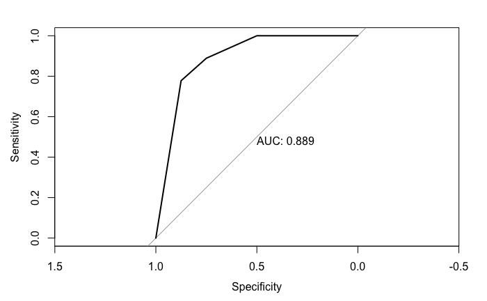

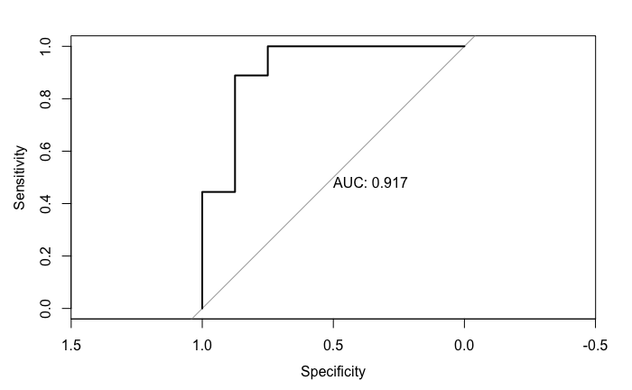

```
[1] "GPT-4 only: Fold 1 AUC: 0.889"
[1] "Model 1: Fold 1 AUC: 0.917"
[1] "Model 2: Fold 1 AUC: 0.931"
```

[output not shown]

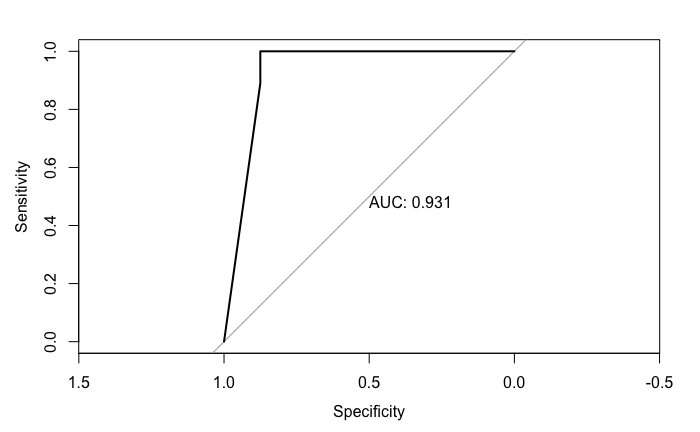

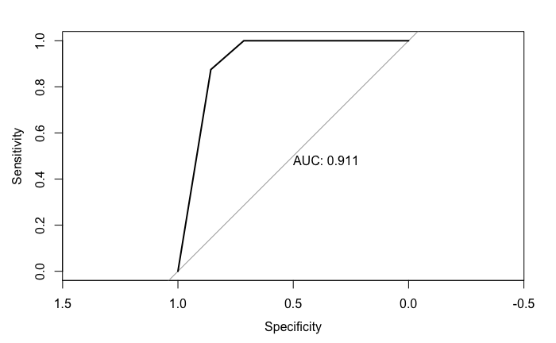

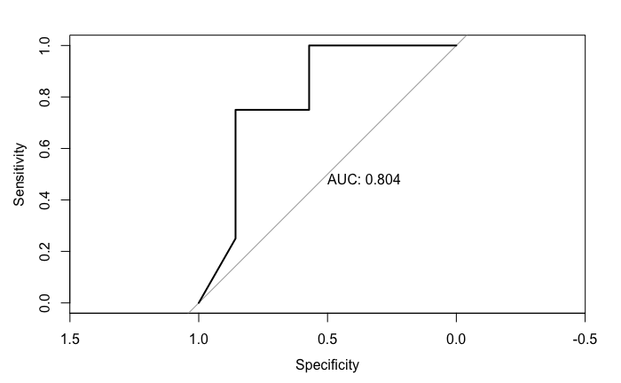

```
[1] "GPT-4 only: Fold 2 AUC: 0.911"
[1] "Model 1: Fold 2 AUC: 0.804"
[1] "Model 2: Fold 2 AUC: 1.000"
```

[output not shown]

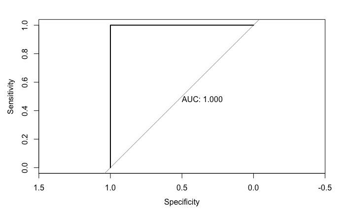

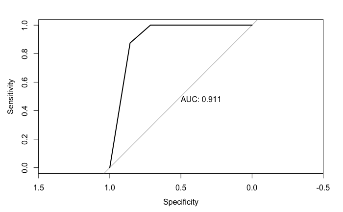

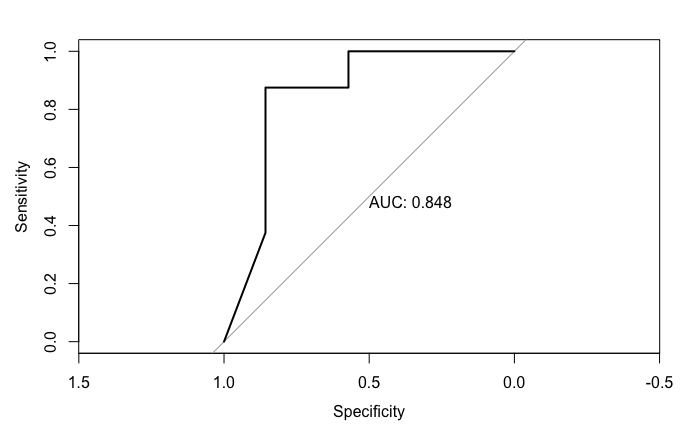

```
[1] "GPT-4 only: Fold 3 AUC: 0.911"
[1] "Model 1: Fold 3 AUC: 0.848"
[1] "Model 2: Fold 3 AUC: 1.000"
```

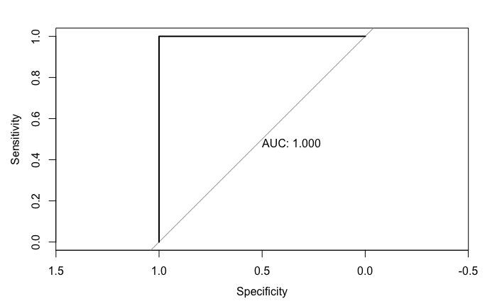

```r
# Get ensembl ID of FABP4
gene.id <- "ENSG00000170323"
stopifnot(gene.id %in% rownames(counts))

# For storing pROC::roc results
gpt4.fold.roc.adult <- list() # GPT-4 only
mod1.fold.roc.adult <- list() # FABP4 only
mod2.fold.roc.adult <- list() # FABP4 + GPT-4

# For storing vst level of FABP4
cv.folds$FABP4.vst <- NA
# For storing predicted probability from the 3 classifiers
cv.folds$gpt4.prob <- NA
cv.folds$mod1.prob <- NA
cv.folds$mod2.prob <- NA

# For storing cutoff value, TN, TP, FN, FP at the Youden's index
gpt4.youden <- list()
mod1.youden <- list()
mod2.youden <- list()

# Iterate through 3 folds
for (k in c(1:3)) {
  test.fold <- cv.folds[cv.folds$fold==k,]
  train.folds <- cv.folds[cv.folds$fold!=k,]

  # Train data
  counts.train <- counts[,train.folds$StudyID]
  keep.train <- rowSums(counts.train>=10) >= (0.2*ncol(counts.train))
  dds.train <- DESeqDataSetFromMatrix(
    countData = counts.train[keep.train,],
    colData = train.folds,
    design = ~1)
  dds.train <- estimateSizeFactors(dds.train)
  dds.train <- estimateDispersions(dds.train)
  vsd.train <- varianceStabilizingTransformation(dds.train) %>%
    assay %>%
    round(., digits=2)
  # Add FABP4 expression
  train.folds$FABP4 <- vsd.train[gene.id,]

  # Fit logistic regression: GPT-4 only
  gpt4.fit <- glm(
    LRTI ~ Versa.LRTI.score,
    data=train.folds,
    family="binomial"
  )

  # Fit logistic regression: FABP4 only
  mod1.fit <- glm(
    LRTI ~ FABP4,
    data=train.folds,
    family="binomial")

  # Fit logistic regression: FABP4 & GPT-4
  mod2.fit <- glm(
    LRTI ~ FABP4 + Versa.LRTI.score,
    data=train.folds,
    family="binomial")

  # Test data
  counts.test <- counts[,test.fold$StudyID]
  dds.test <- DESeqDataSetFromMatrix(
    countData = counts.test[keep.train,],
    colData = test.fold,
    design = ~1)
  dds.test <- estimateSizeFactors(dds.test)
  dispersionFunction(dds.test) <- dispersionFunction(dds.train) # assign the dispersion function from the training data directly
  vsd.test <- varianceStabilizingTransformation(dds.test, blind=FALSE) %>%
    assay %>%
    round(., digits=2)
  # Add FABP4 expression
  test.fold$FABP4 <- vsd.test[gene.id,]

  # Calculate logistic regression's probability
  test.fold$gpt4.prob <- predict(
    gpt4.fit, newdata=test.fold, type="response")
  test.fold$mod1.prob <- predict(
    mod1.fit, newdata=test.fold, type="response")
  test.fold$mod2.prob <- predict(
    mod2.fit, newdata=test.fold, type="response")

  # Store vst level of FABP4
  cv.folds[match(colnames(vsd.test),cv.folds$StudyID),"FABP4.vst"] <- vsd.test[gene.id,]
  # Store probability
  cv.folds[match(test.fold$StudyID,cv.folds$StudyID),"gpt4.prob"] <- test.fold$gpt4.prob
  cv.folds[match(test.fold$StudyID,cv.folds$StudyID),"mod1.prob"] <- test.fold$mod1.prob
  cv.folds[match(test.fold$StudyID,cv.folds$StudyID),"mod2.prob"] <- test.fold$mod2.prob

  # Calculate ROC curve
  gpt4.fold.roc.adult[[k]] <- pROC::roc(
    test.fold$LRTI ~ test.fold$gpt4.prob,
    levels=c("0","1"),
    direction="<",
    plot=TRUE, print.auc=TRUE)
  mod1.fold.roc.adult[[k]] <- pROC::roc(
    test.fold$LRTI ~ test.fold$mod1.prob,
    levels=c("0","1"),
    direction="<",
    plot=TRUE, print.auc=TRUE)
  mod2.fold.roc.adult[[k]] <- pROC::roc(
    test.fold$LRTI ~ test.fold$mod2.prob,
    levels=c("0","1"),
    direction="<",
    plot=TRUE, print.auc=TRUE)
  print(sprintf(
    "GPT-4 only: Fold %d AUC: %.3f", k, gpt4.fold.roc.adult[[k]]$auc))
  print(sprintf(
    "Model 1: Fold %d AUC: %.3f", k, mod1.fold.roc.adult[[k]]$auc))
  print(sprintf(
    "Model 2: Fold %d AUC: %.3f", k, mod2.fold.roc.adult[[k]]$auc))

  # Youden's index
  gpt4.youden[[k]] <- pROC::coords(
    gpt4.fold.roc.adult[[k]],
    x="best", best.method="youden",
    ret=c("threshold","tn","tp","fn","fp")
  )
  mod1.youden[[k]] <- pROC::coords(
    mod1.fold.roc.adult[[k]],
    x="best", best.method="youden",
    ret=c("threshold","tn","tp","fn","fp")
  )
  mod2.youden[[k]] <- pROC::coords(
    mod2.fold.roc.adult[[k]],
    x="best", best.method="youden",
    ret=c("threshold","tn","tp","fn","fp")
  )
}
```

Calculate the mean and s.d. of the AUC

```r
# Get the list of AUCs
gpt4.fold.auc.adult <- unlist(lapply(
  gpt4.fold.roc.adult,
  FUN=function(x) x$auc))
mod1.fold.auc.adult <- unlist(lapply(
  mod1.fold.roc.adult,
  FUN=function(x) x$auc))
mod2.fold.auc.adult <- unlist(lapply(
  mod2.fold.roc.adult,
  FUN=function(x) x$auc))

# GPT-4 only
# Mean
print(mean(gpt4.fold.auc.adult))
```

```
[1] 0.9034392
```

```r
# SD
print(sd(gpt4.fold.auc.adult))
```

```
[1] 0.0126009
```

```r
# Model 1
# Mean
print(mean(mod1.fold.auc.adult))
```

```
[1] 0.8561508
```

```r
# SD
print(sd(mod1.fold.auc.adult))
```

```
[1] 0.0569638
```

```r
# Model 2
# Mean
print(mean(mod2.fold.auc.adult))
```

```
[1] 0.9768519
```

```r
# SD
print(sd(mod2.fold.auc.adult))
```

```
[1] 0.04009377
```

One-sided t-test comparing AUCs

```r
print(t.test(
  mod2.fold.auc.adult, mod1.fold.auc.adult,
  paired=TRUE, alternative="greater"
))
```

```
    Paired t-test

data:  mod2.fold.auc.adult and mod1.fold.auc.adult
t = 2.197, df = 2, p-value = 0.07957
alternative hypothesis: true mean difference is greater than 0
95 percent confidence interval:
 -0.03971998         Inf
sample estimates:
mean difference
      0.1207011
```

```r
print(t.test(
  mod2.fold.auc.adult, gpt4.fold.auc.adult,
  paired=TRUE, alternative="greater"
))
```

```
    Paired t-test

data:  mod2.fold.auc.adult and gpt4.fold.auc.adult
t = 4.625, df = 2, p-value = 0.02185
alternative hypothesis: true mean difference is greater than 0
95 percent confidence interval:
 0.02706372        Inf
sample estimates:
mean difference
      0.0734127
```

Check the distribution of predicred probabilities to verify that they look like proper probability

```
$breaks
 [1] 0.0 0.1 0.2 0.3 0.4 0.5 0.6 0.7 0.8 0.9

$counts
[1] 15  2  0  0  2  4  0  0 24

$density
[1] 3.1914894 0.4255319 0.0000000 0.0000000 0.4255319 0.8510638 0.0000000 0.0000000 5.1063830

$mids
[1] 0.05 0.15 0.25 0.35 0.45 0.55 0.65 0.75 0.85

$xname
[1] "cv.folds$gpt4.prob"

$equidist
[1] TRUE

attr(,"class")
[1] "histogram"
```

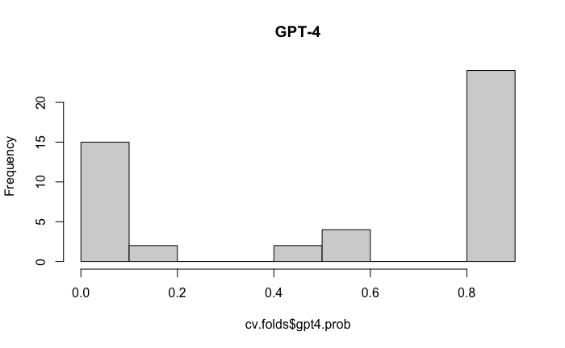

```r
print(hist(cv.folds$gpt4.prob, main="GPT-4", breaks=10))
```

```
$breaks
 [1] 0.0 0.1 0.2 0.3 0.4 0.5 0.6 0.7 0.8 0.9 1.0

$counts
 [1] 7 5 2 3 3 4 4 5 6 8

$density
 [1] 1.4893617 1.0638298 0.4255319 0.6382979 0.6382979 0.8510638 0.8510638 1.0638298 1.2765957 1.7021277

$mids
 [1] 0.05 0.15 0.25 0.35 0.45 0.55 0.65 0.75 0.85 0.95

$xname
[1] "cv.folds$mod1.prob"

$equidist
[1] TRUE

attr(,"class")
[1] "histogram"
```

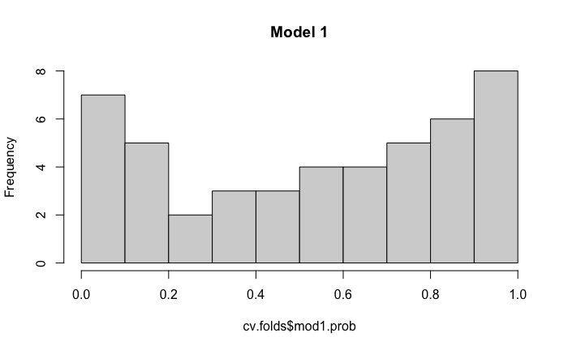

```r
print(hist(cv.folds$mod1.prob, main="Model 1", breaks=10))
```

```
$breaks
 [1] 0.0 0.1 0.2 0.3 0.4 0.5 0.6 0.7 0.8 0.9 1.0

$counts
 [1] 20  0  0  2  0  0  0  3  0 22

$density
 [1] 4.2553191 0.0000000 0.0000000 0.4255319 0.0000000 0.0000000 0.0000000 0.6382979 0.0000000 4.6808511

$mids
 [1] 0.05 0.15 0.25 0.35 0.45 0.55 0.65 0.75 0.85 0.95

$xname
[1] "cv.folds$mod2.prob"

$equidist
[1] TRUE

attr(,"class")
[1] "histogram"
```

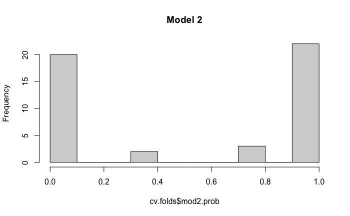

```r
print(hist(cv.folds$mod2.prob, main="Model 2", breaks=10))
```

Export

```r
write.csv(
  cv.folds,
  "./output/validation_classifier_3fold_CV.csv",
  row.names=FALSE
)
```

## Mean ROC curve

Interpolate the ROC to calculate the mean AUC, taking inspiration from https://stats.stackexchange.com/a/187003

```r
# Initialize data frame for storing interpolated TPR and FPR
gpt4.roc.adult.approx <- data.frame(
  fpr.out=seq(0, 1, length.out=100),
  tpr1=0,
  tpr2=0,
  tpr3=0
)
mod1.roc.adult.approx <- gpt4.roc.adult.approx
mod2.roc.adult.approx <- mod1.roc.adult.approx
for (k in 1:3) {
  # GPT-4 only
  fpr <- rev(1-gpt4.fold.roc.adult[[k]]$specificities)
  tpr <- rev(gpt4.fold.roc.adult[[k]]$sensitivities)
  tpr.out <- approx(fpr, tpr,
                    xout=gpt4.roc.adult.approx$fpr.out,
                    method="linear", ties="ordered")
  gpt4.roc.adult.approx[,k+1] <- tpr.out$y

  # Model 1
  fpr <- rev(1-mod1.fold.roc.adult[[k]]$specificities)
  tpr <- rev(mod1.fold.roc.adult[[k]]$sensitivities)
  tpr.out <- approx(fpr, tpr,
                    xout=mod1.roc.adult.approx$fpr.out,
                    method="linear", ties="ordered")
  mod1.roc.adult.approx[,k+1] <- tpr.out$y

  # Model 2
  fpr <- rev(1-mod2.fold.roc.adult[[k]]$specificities)
  tpr <- rev(mod2.fold.roc.adult[[k]]$sensitivities)
  tpr.out <- approx(fpr, tpr,
                    xout=mod2.roc.adult.approx$fpr.out,
                    method="linear", ties="ordered")
  mod2.roc.adult.approx[,k+1] <- tpr.out$y
}
```

Calculate the average TPR and FPR

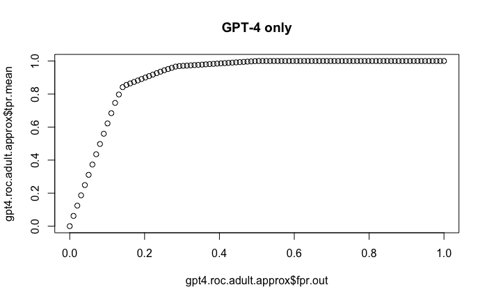

```r
# GPT-4 only
gpt4.roc.adult.approx$tpr.mean <- rowMeans(gpt4.roc.adult.approx[,2:4])
gpt4.roc.adult.approx$tpr.sd <- apply(
  gpt4.roc.adult.approx[,2:4],
  MARGIN=1, FUN=sd
)

gpt4.roc.adult.approx[1,"tpr.mean"] <- 0 # Force the mean ROC to start at (0,0)
plot(gpt4.roc.adult.approx$fpr.out, gpt4.roc.adult.approx$tpr.mean,
     main="GPT-4 only")
```

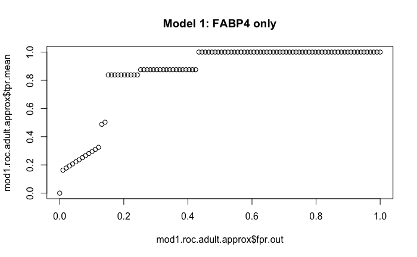

```r
# Model 1
mod1.roc.adult.approx$tpr.mean <- rowMeans(mod1.roc.adult.approx[,2:4])
mod1.roc.adult.approx$tpr.sd <- apply(
  mod1.roc.adult.approx[,2:4],
  MARGIN=1, FUN=sd
)

mod1.roc.adult.approx[1,"tpr.mean"] <- 0 # Force the mean ROC to start at (0,0)
plot(mod1.roc.adult.approx$fpr.out, mod1.roc.adult.approx$tpr.mean,
     main="Model 1: FABP4 only")
```

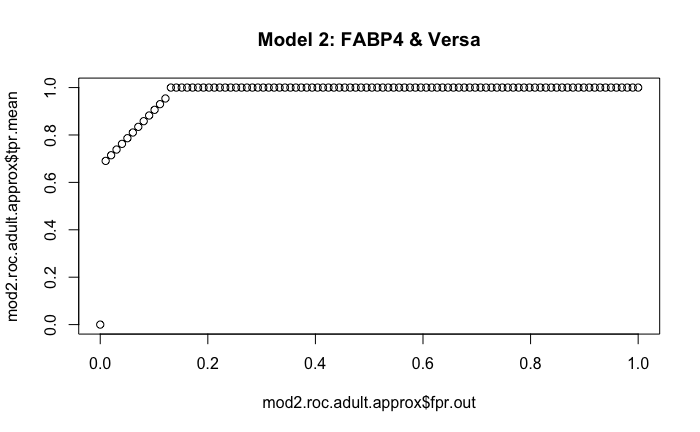

```r
# Model 2
mod2.roc.adult.approx$tpr.mean <- rowMeans(mod2.roc.adult.approx[,2:4])
mod2.roc.adult.approx$tpr.sd <- apply(
  mod2.roc.adult.approx[,2:4],
  MARGIN=1, FUN=sd
)
mod2.roc.adult.approx[1,"tpr.mean"] <- 0 # Force the mean ROC to start at (0,0)
plot(mod2.roc.adult.approx$fpr.out, mod2.roc.adult.approx$tpr.mean,
     main="Model 2: FABP4 & Versa")
```

Plot interpolated ROC

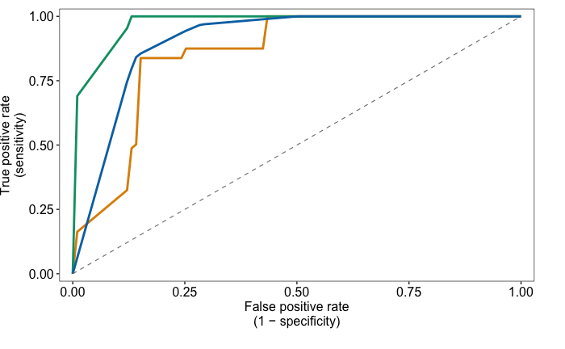

```r
p <- ggplot()

# Model 1
p <- p + geom_line(
  data=mod1.roc.adult.approx,
  aes(x=fpr.out, y=tpr.mean),
  col=color.fabp4, linewidth=1)

# Model 2
p <- p + geom_line(
  data=mod2.roc.adult.approx,
  aes(x=fpr.out, y=tpr.mean),
  col=color.integrated, linewidth=1)

# GPT-4
p <- p + geom_line(
  data=gpt4.roc.adult.approx,
  aes(x=fpr.out, y=tpr.mean),
  col=color.gpt4, linewidth=1)

# Add the diagonal line
p <- p +
  geom_segment(
    aes(x=0,xend=1,y=0,yend=1),
    linetype="dashed", col="grey50", linewidth=0.4)

# Formatting
p <- p +
  labs(x="False positive rate\n(1 \u2212 specificity)",
       y="True positive rate\n(sensitivity)") +
  scale_x_continuous(limits=c(-0.03,1.03), expand=c(0,0)) +
  scale_y_continuous(limits=c(-0.03,1.03), expand=c(0,0)) +
  theme_bw() +
  theme(
    plot.title = element_text(hjust = 0.5, size=12, face="plain"),
    axis.text = element_text(size=12, color="black"),
    text = element_text(size=12, family="Arial"),
    panel.grid.major = element_blank(),
    panel.grid.minor = element_blank(),
    plot.margin = unit(c(0.3,1,0.7,0), "cm")
  )
p
ggsave(
  "./output/validation_both_mean_roc.svg",
  plot=p,
  width=3.55, height=3.57, units="in")
```

## Youden’s index

Statistics at Youden’s index

```r
print(bind_rows(gpt4.youden))
```

|  | threshold | tn | tp | fn | fp |
| --- | --- | --- | --- | --- | --- |
| threshold...1 | 0.6488493 | 7 | 7 | 2 | 1 |
| threshold...2 | 0.6991062 | 6 | 7 | 1 | 1 |
| threshold...3 | 0.7108306 | 6 | 7 | 1 | 1 |

```r
print(bind_rows(mod1.youden))
```

|  | threshold | tn | tp | fn | fp |
| --- | --- | --- | --- | --- | --- |
| threshold...1 | 0.5381358 | 7 | 8 | 1 | 1 |
| threshold...2 | 0.7838584 | 6 | 6 | 2 | 1 |
| threshold...3 | 0.5505696 | 6 | 7 | 1 | 1 |

```r
print(bind_rows(mod2.youden))
```

|  | threshold | tn | tp | fn | fp |
| --- | --- | --- | --- | --- | --- |
| threshold...1 | 1.377104e-06 | 7 | 9 | 0 | 1 |
| threshold...2 | 5.260190e-01 | 7 | 8 | 0 | 0 |
| threshold...3 | 5.401363e-01 | 7 | 8 | 0 | 0 |

# Compare all predictions to true diagnosis

## ICU initial diagnosis

```r
# Number of patients per predicted and true LRTI diagnosis
temp1 <- metadata %>%
  select(StudyID, LRTI, Clinical_LRTI) %>%
  group_by(Clinical_LRTI, LRTI) %>%
  summarise(count = n(), .groups = 'drop')
print(temp1)
```

| Clinical_LRTI | LRTI | count |
| --- | --- | --- |
| N | 0 | 15 |
| Y | 0 | 7 |
| Y | 1 | 25 |

Plot confusion matrix

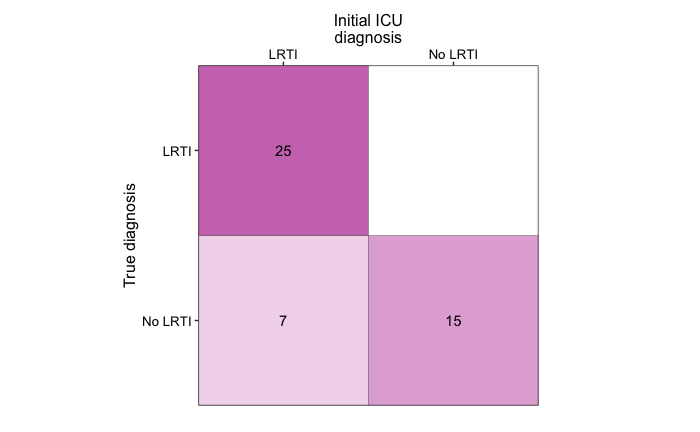

```r
p.initial <- ggplot(
  data=temp1,
  aes(x=Clinical_LRTI, y=LRTI)) +
  geom_tile(aes(fill=count), color="black") +
  geom_text(aes(label=count), vjust = 0.5) +
  labs(x="Initial ICU\ndiagnosis",
       y="True diagnosis") +
  scale_fill_gradient(
    low="white", high=color.initial,
    limits=c(0,25), guide="none") +
  scale_x_discrete(
    expand=c(0,0), limits=c("Y","N"),
    labels=c("LRTI","No LRTI"), position="top") +
  scale_y_discrete(expand=c(0,0), labels=c("No LRTI","LRTI")) +
  coord_fixed(ratio=1) +
  theme_bw() + my.theme.cm
p.initial
```

## GPT-4

Compare GPT-4 prediction to true diagnosis (threshold is LRTI score >=1)

```r
# Number of patients per predicted and true LRTI diagnosis
temp1 <- metadata %>%
  select(StudyID, LRTI, Versa.LRTI.score) %>%
  mutate(gpt4.pred=as.factor(Versa.LRTI.score>=1)) %>%
  group_by(gpt4.pred, LRTI) %>%
  summarise(count = n(), .groups = 'drop')
print(temp1)
```

| gpt4.pred | LRTI | count |
| --- | --- | --- |
| FALSE | 0 | 12 |
| TRUE | 0 | 10 |
| TRUE | 1 | 25 |

Plot confusion matrix

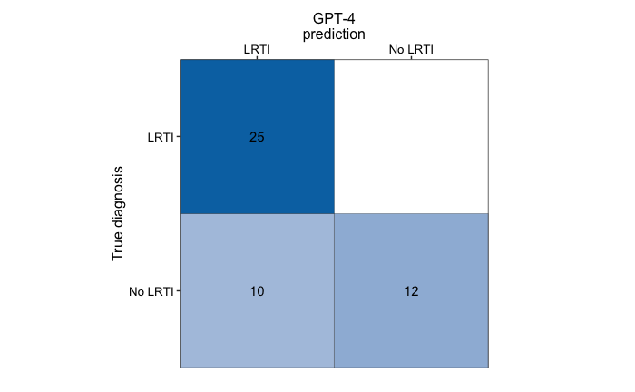

```r
p.gpt4 <- ggplot(
  data=temp1,
  aes(x=gpt4.pred, y=LRTI)) +
  geom_tile(aes(fill=count), color="black") +
  geom_text(aes(label=count), vjust = 0.5) +
  labs(x="GPT-4\nprediction",
       y="True diagnosis") +
  scale_fill_gradient(
    low="white", high=color.gpt4,
    limits=c(0,25), guide="none") +
  scale_x_discrete(
    expand=c(0,0), limits=c("TRUE","FALSE"),
    labels=c("LRTI","No LRTI"), position="top") +
  scale_y_discrete(expand=c(0,0), labels=c("No LRTI","LRTI")) +
  coord_fixed(ratio=1) +
  theme_bw() + my.theme.cm
p.gpt4
```

## FABP4 classifiers

I will plot the confusion matrix to compare different predictions to true diagnosis

Compare FABP4 prediction to true diagnosis

```r
# Number of patients per predicted and true LRTI diagnosis
temp1 <- cv.folds %>%
  select(StudyID, LRTI, mod1.prob) %>%
  mutate(mod1.pred=as.factor(mod1.prob>=0.5)) %>%
  group_by(mod1.pred, LRTI) %>%
  summarise(count = n(), .groups = 'drop')
print(temp1)
```

| mod1.pred | LRTI | count |
| --- | --- | --- |
| FALSE | 0 | 16 |
| FALSE | 1 | 4 |
| TRUE | 0 | 6 |
| TRUE | 1 | 21 |

```r
# Calculate proportion
temp1 <- temp1 %>%
  group_by(mod1.pred) %>%
  mutate(prop=count/sum(count)) %>%
  ungroup()
print(temp1)
```

| mod1.pred | LRTI | count | prop |
| --- | --- | --- | --- |
| FALSE | 0 | 16 | 0.8000000 |
| FALSE | 1 | 4 | 0.2000000 |
| TRUE | 0 | 6 | 0.2222222 |
| TRUE | 1 | 21 | 0.7777778 |

Compare FABP4 + GPT-4 prediction to true diagnosis

```r
# Number of patients per predicted and true LRTI diagnosis
temp3 <- cv.folds %>%
  select(StudyID, LRTI, mod2.prob) %>%
  mutate(mod2.pred=as.factor(mod2.prob>=0.5)) %>%
  group_by(mod2.pred, LRTI) %>%
  summarise(count = n(), .groups = 'drop')
print(temp3)
```

| mod2.pred | LRTI | count |
| --- | --- | --- |
| FALSE | 0 | 21 |
| FALSE | 1 | 1 |
| TRUE | 0 | 1 |
| TRUE | 1 | 24 |

```r
# Calculate proportion
temp3 <- temp3 %>%
  group_by(mod2.pred) %>%
  mutate(prop=count/sum(count)) %>%
  ungroup()
print(temp3)
```

| mod2.pred | LRTI | count | prop |
| --- | --- | --- | --- |
| FALSE | 0 | 21 | 0.95454545 |
| FALSE | 1 | 1 | 0.04545455 |
| TRUE | 0 | 1 | 0.04000000 |
| TRUE | 1 | 24 | 0.96000000 |

Plot confusion matrices of FABP4 and integrated classifiers

[figure not shown]

```r
p.fabp4 <- ggplot(
  data=temp1,
  aes(x=mod1.pred, y=LRTI)) +
  geom_tile(aes(fill=count), color="black") +
  geom_text(aes(label=count), vjust = 0.5) +
  labs(x="FABP4-only\nprediction",
       y="True diagnosis") +
  scale_fill_gradient(
    low="white", high=color.fabp4,
    limits=c(0,25), guide="none") +
  scale_x_discrete(
    expand=c(0,0), limits=c("TRUE","FALSE"),
    labels=c("LRTI","No LRTI"), position="top") +
  scale_y_discrete(expand=c(0,0), labels=c("No LRTI","LRTI")) +
  coord_fixed(ratio=1) +
  theme_bw() + my.theme.cm
p.integrated <- ggplot(
  data=temp3,
  aes(x=mod2.pred, y=LRTI)) +
  geom_tile(aes(fill=count), color="black") +
  geom_text(aes(label=count), vjust = 0.5) +
  labs(x="FABP4 + GPT-4\nprediction",
       y="True diagnosis") +
  scale_fill_gradient(
    low="white", high=color.integrated,
    limits=c(0,25), guide="none") +
  scale_x_discrete(
    expand=c(0,0), limits=c("TRUE","FALSE"),
    labels=c("LRTI","No LRTI"), position="top") +
  scale_y_discrete(expand=c(0,0), labels=c("No LRTI","LRTI")) +
  coord_fixed(ratio=1) +
  theme_bw() + my.theme.cm
p.fabp4 + p.integrated + plot_layout(nrow=1)
```

## All comparisons

Export all confusion matrices

```r
ggsave(
  "./output/validation_all_confusion_matrix.svg",
  plot=p.initial + p.fabp4 + p.gpt4 + p.integrated + plot_layout(nrow=2),
  width=8.5, height=4.7, units="in")
```